# Coffee Analysis: Create Model to predict Coffee Aroma

Ghadi K

22-10-2020

# Data Introduction

This report is done on the coffee ratings dataset it contains reviews of 1312 arabica and 28 robusta coffee beans from the Coffee Quality Institute trained reviewers. The features include and used in this report are Aroma grade one of the quality measures and Country of Origin from farm metadata that tells us where the bean came from.

# Descriptive Statistics

First Seeing the correlation between columns I chose from dataset. This helped me chose the variables that I will use in my prediction.

|  | Aroma | Total.Cup.Points | Flavor | Acidity | Sweetness | Aftertaste |
| --- | --- | --- | --- | --- | --- | --- |
| Aroma | 1 | 0.791626802993287 | 0.813259456068156 | 0.723582168215678 | 0.253493252558376 | 0.777056294087063 |
| Total.Cup.Points | 0.791626802993287 | 1 | 0.874279176771593 | 0.797024237243462 | 0.554028954592482 | 0.860656402132393 |
| Flavor | 0.813259456068156 | 0.874279176771593 | 1 | 0.816688334646004 | 0.291065491899407 | 0.895671753865746 |
| Acidity | 0.723582168215678 | 0.797024237243462 | 0.816688334646004 | 1 | 0.261854279974493 | 0.792255189024962 |
| Sweetness | 0.253493252558376 | 0.554028954592482 | 0.291065491899407 | 0.261854279974493 | 1 | 0.266408566328573 |
| Aftertaste | 0.777056294087063 | 0.860656402132393 | 0.895671753865746 | 0.792255189024962 | 0.266408566328573 | 1 |

I found that Aroma and Flavor are highly correlated(0.813) so I choose to work with this variables.

# Data Visualization

Now I visualize variables to understand there relationship better.

## Scatter Plot

By plotting a Scatter plot it is more clear to see the correlation between Aroma and Flavor since The closer the data points to make a straight line the stronger the relationship between the two variables I chose.

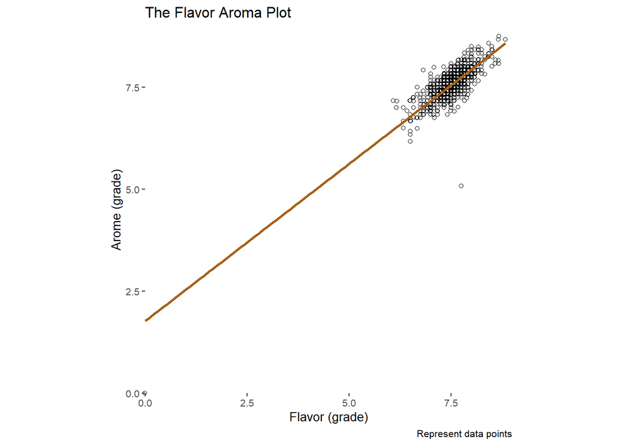

# Linear Regression Model

Since the relation for my variables is linear and they both continuous I choose the Linear Regression Model for my prediction. So the question now that I will try to find the answer for is

Can Flavor grade predict coffee Aroma grade?

Is a coffee with good taste always has a good aroma as well?

Dose Acidity will improve the prediction and model preformance?